# Reproducible research

## Reproducibility of scientific research

Concerns about lack of reproducibility of scientific research ([Baker, Nature 2016](https://www.nature.com/articles/533452a)).

[figure not shown]

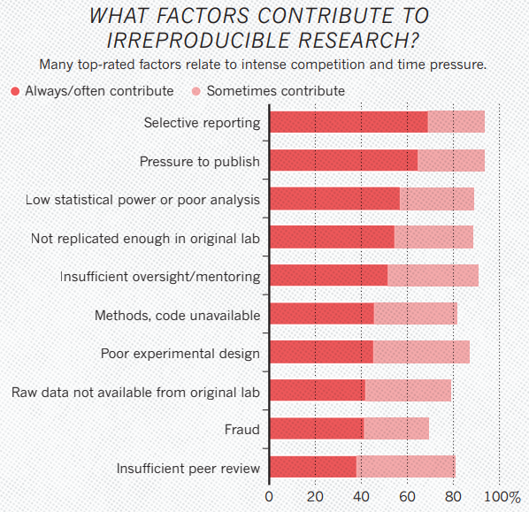

## Computational reproducibility (lack of)

Reproducibility of results when the original data is available.

- [Ioannidis, Nature Genetics 2009](https://www.nature.com/articles/ng.295):

  > Evaluated 18 articles on microarray gene expression profiling published in Nature Genetics in 2005–2006. We reproduced 2, and 6 partially or with some discrepancies; **10 could not be reproduced**.

  > Failure to reproduce were mostly due to incomplete data annotation or **incomplete specification of data processing and analysis**.
- [Hardwike et al., RSOS 2018](https://www.ncbi.nlm.nih.gov/pmc/articles/PMC6124055/))

  > For 22/35 articles all values were reproduced, but 11 required author assistance.

  > For 13/35 articles at least one value could not be reproduced **despite author assistance**.

  > Suboptimal data curation, **unclear analysis specification and reporting errors** can impede analytic reproducibility, undermining the utility of data sharing and the credibility of scientific findings.

## Literate programming

A single document (file) that combines **text** and **R code**.

R packages to help with LP:

- `knitr`: report generation from combined text and R code.
- `Rmarkdown`: simple formatting syntax for text and code.
- `tinytext`: needed to create pdf documents.

You should install `tinytext` now !

## Creating a report

In RStudio:

1. `File > New file > R mardown...`
2. A dialog will open, where you should:
   - Provide a title and author in the dialog
   - Leave the default output format (HTML)
   - Click OK
3. When a new `Untitled1` tab opens, click the `Knit` button.
4. Give a name to the file: it **should not** containg blank spaces!
5. A new HTML report should appear in a new window.
6. This is an HTML file that has been added to your working directory.

## Report output formats

- HTML
- pdf
- MS Word

Unfold the `knit` button to pick the desired one.

## Rmarkdown document (.Rmd)

Structure of an .Rmd document:

- YAML header, delimited by three dashes (`---`)
- Text, with R markdown formatting
- Code chunks for R code, with optional name and chunk options

## YAML header

Some possibilities (some of them do not work in some output formats):

```
---
title: "Birth weight"
author: "Albert Cobos"
date: "04/08/2021"
output:
  pdf_document:
    toc: true
    toc_depth: 2
---
```

For more YAML options, see [here](https://bookdown.org/yihui/rmarkdown/html-document.html)

## Text, with R markdown formatting

- Use hashes (`##`) for section headers: the number of hashes determine the level of header.
- `**boldface**` or `__boldface__` become **boldface**
- `*italics*` or `_italics_` become *italics*
- `<https://cdb.clinic.cat/>` becomes https://cdb.clinic.cat/
- `[Clinic CDB](https://cdb.clinic.cat/)` becomes [Clinic CDB](https://cdb.clinic.cat/)
- …

For more R markdown formatting options, see:

- the [R Markdown reference guide](https://www.rstudio.com/wp-content/uploads/2015/03/rmarkdown-reference.pdf?_ga=2.31117371.589981273.1627977413-1000639518.1610891435), or
- the [R Markdown cheatsheet](https://www.rstudio.com/wp-content/uploads/2015/02/rmarkdown-cheatsheet.pdf)

## Chunk options

Options affecting text output of R code:

- `echo = FALSE`: to suppress the R code (default is `TRUE`, showing the R code).
- `message = FALSE`: to suppress R messages (default is `TRUE`, showing messages).
- `warning = FALSE`: to suppress R warnings (default is `TRUE`, showing warnings).
- `error = FALSE`: to suppressed R errors (default is `TRUE`, showing errors).
- `results = 'asis'`: to write text results unaltered (default is `markup`, writing text according to output format).

## Chunk options

Options affecting plots:

- `fig.align = 'center'`: To center figures (default is `'default'`, which does not make any alignment adjustment; other possible values are `'left'` or `'right'`).
- `fig.cap = 'A caption for the figure'`: To provide, within quotes, a caption for the figure (default is `NULL`). Figures with a caption will be automatically numbered, and can be referenced in the text (in pdf output documents).
- `fig.height =` *n*, `fig.width =` *n*: Set the figure height and width to the number of inches provided (*n*).

## Chunk options

- Can be specified in any particular code chunk, and then they will be applied to this chunk only, other chunks remaining unaffected
- Can be set with function `knitr::opts_chunk$set()` in the first code chunk, an then they will affect all subsequent code chunks (unless overwritten in a particular code chunk)

Useful first code chunk:

````
```{r setup, include = FALSE}
knitr::opts_chunk$set(echo = FALSE, message = FALSE, warning = FALSE,
                      comment=NA, fig.align = 'center')

```
````

For more chunk options, see [here](https://yihui.org/knitr/options/)

## Slides presentation

R Markdown can be used to produce slide presentations in several output formats:

- HTML: IOslides, and Slidy
- pdf: Beamer
- MS PowerPoint

## Creating an IOslides presentation

In RStudio:

1. `File > New File > R Markdown...`
2. A dialog will open, where you should:
   - Choose `Presentation` in the left panel
   - Provide a title and author in the dialog
   - Leave the default output format HTML(ioslides)
   - Click OK
3. When a new `Untitled1` tab opens, click the `Knit` button.
4. Give a name to the file: it **should not** containg blank spaces!
5. A new HTML presentation should appear in a new window.
6. This is an HTML file that has been added to your working directory.

## Exercise

1. Create a .pdf report on the birth weight data in `MASS::birthwt`:
   - In the first setup chunk:
     - define general chunk options
     - load the packages you need with `library()`
     - read and prepare the data (see code in next slide)
   - Write an **Introduction** section with some text.
   - Write a **Methods** section with some text.
   - Write a **Results** section with at least two graphics of your choice, and some sentences interpreting the graphics.
2. Create an IOslides presentation with similar contents as exercise 1.

## Get and prepare the `MASS::birthwt` dataset

```r
d <- MASS::birthwt %>%
  mutate(low = factor(low, levels = 1:0, labels = c("low", "normal")),
         race = factor(race, levels = 1:3, labels = c("white", "black", "other")),
         smoke = factor(smoke, levels = 1:0, labels = c("smoker", "non-smoker")),
         ui = factor(ui, levels = 1:0, labels = c("UI", "no-UI")),
         ht = factor(ht, levels = 1:0, labels = c("AHT", "no-AHT"))) %>%
  rename(bw = low)

head(d)
```

```
       bw age lwt  race      smoke ptl     ht    ui ftv  bwt
85 normal  19 182 black non-smoker   0 no-AHT    UI   0 2523
86 normal  33 155 other non-smoker   0 no-AHT no-UI   3 2551
87 normal  20 105 white     smoker   0 no-AHT no-UI   1 2557
88 normal  21 108 white     smoker   0 no-AHT    UI   2 2594
89 normal  18 107 white     smoker   0 no-AHT    UI   0 2600
91 normal  21 124 other non-smoker   0 no-AHT no-UI   0 2622
```